# MATH 1906, Chaos in Dynamical Systems

## 1- Motivation and Introduction

## Lecturer: Eduardo G. Altmann

Key concepts are marked in red .  
More on Jupyter notebooks: www.jupyter.org  
Webpage of this unit: http://www.maths.usyd.edu.au/u/UG/JM/MATH1906/  
Codes for this topic: https://github.com/edugalt/math1906

# Information about these lectures

## Goals:

```
- Introduction to dynamical systems
- Relation between determinism and predictability
- The tasks and goals of Science
```

# 1. Introduction: the birth of dynamical systems

## 1.1 - Pre-Newtonian description of motion

Cosmological models  
**Ptolomy**  
**Copernicus**  
**Kepler**

Ballistic motion  
**Galileu:** Cannon balls and free movement

### All these curves are conic sections

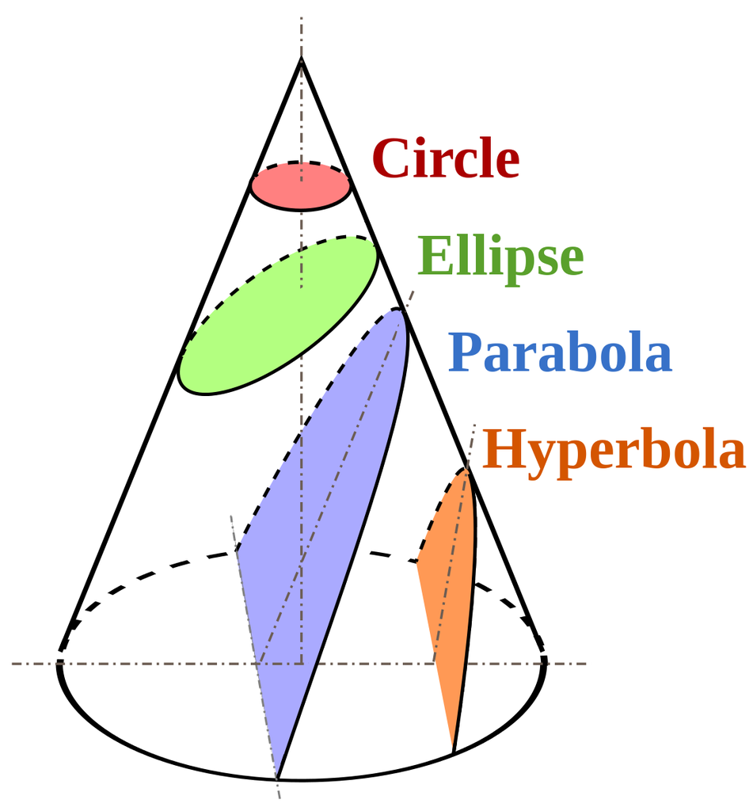

```python
from IPython.display import Image
Image("/home/ega/Downloads/Conic_Sections.png",width=300)
#Source: Wikipedia
```

### Halley visits Newton in Cambridge (August 1684):

*"Dr. Halley asked him what he thought the curve would be that would be described by the Planets supposing the force of attraction towards the Sun to be reciprocal to the square of their distance from it. Sir Isaac Newton replied immediately that it would be an Ellipsis, the Dr. struck with joy and amazement and aksed him how he knew it, Why saith he I have **calculated** it..."*

## 1.2 Newtonian description of motion (and Science!)

1.How to compute motion:

$$F = ma = m \ddot{x} \equiv m \frac{d^2 x}{dt^2}$$

2.Expression for the force $F$: $$ F_G = -G \frac{mM}{r^2}$$

3.Result: unify earth and sky!

### New interpretation of motion (Science):

$$ m \ddot{x} = F(x) $$

## Assumed implications for Science (Physics)

The behaviour of matter results from the forces acting on it.

1) Knowing the forces (equation of motion) we know everything about the future evolution of the system.

2) The goal of Physics is to reveal the fundamental forces of nature.

### Quote:

*"We may regard the present state of the universe as the effect of its past and the cause of its future. An intellect which at a certain moment would know all forces that set nature in motion, and all positions of all items of which nature is composed, if this intellect were also vast enough to submit these data to analysis, it would embrace in a single formula the movements of the greatest bodies of the universe and those of the tiniest atom; for such an intellect nothing would be uncertain and the future just like the past would be present before its eyes."*  
— Pierre Simon Laplace (1795)

## Goal of these lectures:

show that points 1. and 2. above are **wrong!**

## How?

We'll consider a simple system in which we know the equations of motion, and then show that:

~1. there are intrinsic limitations on our knowledge about the future of dynamical system.

~2. there are many (unexpected and interesting) things to discover (beyond "fundamental forces/particles").